# Cheminformatics

## 11/2/2021

*Cheminformatics (also known as chemoinformatics, chemioinformatics and chemical informatics) is the use of computer and informational techniques applied to a range of problems in the field of chemistry.* --Wikipedia

# Open Source Cheminformatics

- rdkit http://www.rdkit.org
  - BSD License
  - Relatively new, very nicely architected C++ backend
  - Actively developed
  - Native Python interface
- OpenBabel http://openbabel.org
  - GNU License
  - Older (forked from OpenEye in 2001), a bit crufty and complicated
  - Lots of functionality (e.g., support for more than 100 file formats)
  - Python interface is through SWIG (auto-generated) bindings to C/C++
  - Includes standalone programs: babel, obabel, etc.
- Pybel
  - A native, user-friendly python interface to OpenBabel
  - Limited functionality (but can always fallback to OpenBabel)
  - Simplest to use
  - **Note:** Pybel is installed as part of openbabel. There is a completely unrelated python package called PyBEL that is *not* what you want

# File Formats

### 2D

[figure not shown]

SMILES

### 3D

[figure not shown]

pdb, sdf, mol2

# Simplified Molecular Input Line Entry System (SMILES)

### Atoms

Specified by their atomic symbols inside brackets

- [Au], [Fe], [Zn], etc

No brackets needed for organic subset: B, C, N, O, P, S, F, Cl, Br, and I

Aromatic atoms are lower case: c1ccccc1

### Bonds

- Single **-**
- Double **=**
- Triple **#**
- Aromatic **:**

Single and aromatic can be omitted. E.g ethane (C2H6) is CC.

# SMILES, cont.

[figure not shown]

## Branches

Parentheses denote branches and can be nested.

Example: **SC(N)CO**

## Cycles

Break a bond in the cycle and use a digit to label the break.

[figure not shown]

As long as rings are separate, digits can be reused. Aromatic rings use lower-case e.g. c1ccccc1 is benzene

# SMILES, cont.

## Disconnections

A period `.` separates nonbonded molecules.

**[Na+].[Cl-]**

## Isomeric Smiles

Slashes (`/ \`) denote configuration around double bonds.

At (`@`) denotes configuration around chiral centers.

[figure not shown]

# Drawing

All but the simplest smiles can be challenging to interpret (especially if chirality is included). Fortunately, you can use pybel (or molecular viewers like [MarvinView](https://www.chemaxon.com/products/marvin/marvinview/)) to convert them to their 2D representation.

Example: **CC(NC1=CC=C(O)C=C1)=O**

[figure not shown]

# SMARTS

Regular expressions for molecules.

All SMILES are SMARTS (exact matches). Additionally, SMARTS support

- wild cards
  - `C~*~C` any atom can be between two carbons using any (~) bond
  - `a1aaaaa1` any aromatic 6 atom ring
- property testing
  - `[R]` atom in a ring
  - `[#6]` atomic number is 6 (matches aromatic or aliphatic)
  - `[D3]` atom with three explicit bonds (degree)
- logical operators (not - **!**, and - **&** **;**, or - **,**)
  - `[!C&R]` not aliphatic carbon and in ring
  - `[F,Cl,Br,I]` one of the first four halogens
- matching an atomic environment ('recursive' SMARTS)
  - `[$(*O);$(*C)]` this matches one atom that is bound to both C and O

# Pybel Input/Output

`pybel.readstring`

Takes a format and string with molecular data in it and returns a single molecule.

```
4
```

For simple output, use the molecule's `write` method, which takes the format

```
 OpenBabel10312213312D

  4  3  0  0  0  0  0  0  0  0999 V2000
    0.0000    0.0000    0.0000 C   0  0  0  0  0  0  0  0  0  0  0  0
    0.0000    0.0000    0.0000 C   0  0  0  0  0  0  0  0  0  0  0  0
    0.0000    0.0000    0.0000 C   0  0  0  0  0  0  0  0  0  0  0  0
    0.0000    0.0000    0.0000 C   0  0  0  0  0  0  0  0  0  0  0  0
  1  2  1  0  0  0  0
  2  3  1  0  0  0  0
  3  4  1  0  0  0  0
M  END
$$$$
```

# `pybel.readfile`

`pybel.readfile`

Takes a format and file name and returns an *iterator* over all the molecules in the file.

```
14
```

[figure not shown]

```
N#Cc1c(O)c2C(=O)c3ccccc3C(=O)c2c(c1C#N)O	NSC27034
N#Cc1cc2SCCSCCCSCCSc2cc1C#N	NSC680721
N#Cc1cc2CN(CCN(CCN(CCN(Cc2cc1C#N)S(=O)(=O)c1ccc(cc1)C)S(=O)(=O)c1ccc(cc1)C)S(=O)(=O)c1ccc(cc1)C)S(=O)(=O)c1ccc(cc1)C	NSC673657
N#Cc1cc2/C(=N\c3cccc(n3)N)/N=C(c2cc1C#N)Nc1cccc(n1)N	NSC666078
N#Cc1c(OC)ccc(c1C#N)O.COc1ccc(c(c1C#N)C#N)OC	NSC618324
N#Cc1c(C#N)c(O)c2c(c1O)c(N)ccc2	NSC320651
N#Cc1cc(ccc1C#N)NC(=O)CCCC(=O)Nc1ccc(c(c1)C#N)C#N	NSC309816
N#Cc1c(C#N)c(O)c(c(c1O)Cl)Cl	NSC172566
N#Cc1c(C#N)c(O)c2c(c1O)cccc2	NSC128281
N#Cc1cc(ccc1C#N)[N+](=O)[O-]	NSC123374
N#Cc1cc(ccc1C#N)Oc1ccc(c(c1)C#N)C#N	NSC94808
N#Cc1c2c(cc(c1C#N)[N+](=O)[O-])n(c1c2cccc1)C	NSC92934
N#Cc1c(O)ccc(c1C#N)O	NSC43554
N#Cc1ccccc1C#N	NSC17562
```

# `pybel.Outputfile`

To output many molecules to the same file, use `pybel.Outputfile`

# Molecules

The molecule object provides a number of methods and access to the molecules atoms and bonds.

```
6 6 6 6 6 6 6 7 6 7
```

Atom properties include `atomicmass`, `atomicnum`, `coords`, `formalcharge`, `hyb`, `isotope`, `partialcharge` and `degree`

Atoms can also be accessed in `mol.atoms`

# SMARTS Matching

SMARTS matching is done by initializing a `pybel.Smarts` object with a SMARTS expression. This can then be applied to any molecule to identify the matching atoms.

```
[(1, 6, 5, 4, 3, 2)]
```

The returned matches are atom indices that can be accessed through `mol.atoms`

```
5
8
```

[figure not shown]

# Molecular Properties

```
128.13076
```

```
{'abonds': 6.0, 'atoms': 10.0, 'bonds': 10.0, 'cansmi': nan, 'cansmiNS': nan, 'dbonds': 0.0, 'formula': nan, 'HBA1': 2.0, 'HBA2': 2.0, 'HBD': 0.0, 'InChI': nan, 'InChIKey': nan, 'L5': nan, 'logP': 1.42996, 'MR': 35.872, 'MW': 128.13076, 'nF': 0.0, 'rotors': 0.0, 's': nan, 'sbonds': 2.0, 'smarts': na…
```

```
1.42996
```

# Lipinski's Rule of Five

In 1997 Christopher Lipinski analyzed existing drugs and came up with a set of molecular property rules for classifying a small molecule as *drug-like*.

- No more than 5 hydrogen bond donors
- No more than 10 hydrogen bond acceptors
- Molecular weight less than 500 daltons
- Partition coefficient logP less than 5
- There is no fifth rule

```
True
True
False
True
True
True
True
True
True
True
True
True
True
True
```

# Fingerprints

A *molecular fingerprint* reduces the chemical features of a molecule into a *bit vector*. The features of the fingerprint correspond to a bit in the vector. This bit is set if the compound has that feature.

The most common type of fingerprint is a Daylight style fingerprint where all the paths (up to a given length) are enumerated and *hashed* to their bit positions.

[figure not shown]

# Fingerprints, cont.

Bit vectors can easily be compared, most commonly with the Tanimoto coefficient: $$\frac{A \cap B}{A \cup B}$$

This provides a quantitative measure of *chemical similarity*.

Similarity search is a surprisingly effective mechanism of virtual screening (given enough data).

```
openbabel.pybel.Fingerprint
```

```
[75, 82, 224, 279, 296, 299, 348, 440, 442, 474, 503, 598, 656, 671, 711, 716, 728, 870, 906, 913, 937]
```

# Chemical Similarity

### Tanimoto coefficient

$\Large \frac{A \cap B}{A \cup B}$ 1.0 means identical

To calculate the Tanimoto similarity between two fingerprints, use the **|** operator

```
0.28
0.3
0.19626168224299065
0.12138728323699421
0.5
0.4666666666666667
0.29577464788732394
0.42857142857142855
0.6176470588235294
0.4117647058823529
0.4772727272727273
0.22826086956521738
0.6363636363636364
1.0
```

# 2D -> 3D

```
(0.7656749137001738, -0.08415478296300143, -0.15465954760011352)
(1.2410627944678445, 0.05282849408781525, 0.10746537534097979)
```

# `sdf` Molecules

```
10
```

```
(-0.5939, -56.8911, 14.3139)
```

```
ZINC78996542


 39 44  0  0  0  0  0  0  0  0999 V2000
   -0.5939  -56.8911   14.3139 C   0  0  0  0  0  0  0  0  0  0  0  0
    2.3154  -57.8883   15.8741 C   0  0  0  0  0  0  0  0  0  0  0  0
   -0.3628  -55.5394   14.9296 C   0  0  0  0  0  0  0  0  0  0  0  0
    1.0440  -55.7357   15.4805 C   0  0  0  0  0  0  0  0  0  0  0  0
    0.3058  -57.7869   14.5684 N   0  0  0  0  0  0  0  0  0  0  0  0
    1.2724  -57.1748   15.3144 N   0  0  0  0  0  0  0  0  0  0  0  0
    3.1864  -57.3893   16.5881 O   0  0  0  0  0  0  0  0  0  0  0  0
   -6.5650  -58.0576   12.9536 C   0  0  0  0  0  0  0  0  0  0  0  0
   -6.4112  -58.0403   11.5707 C   0  0  0  0  0  0  0  0  0  0  0  0
   -5.4635  -57.8375   13.7859 C   0  0  0  0  0  0  0  0  0  0  0  0
   -5.1560  -57.8031   11.0185 C   0  0  0  0  0  0  0  0  0  0  0  0
   -4.1883  -57.5962   13.2480 C   0  0  0  0  0  0  0  0  0  0  0  0
   -4.0573  -57.5833   11.8565 C   0  0  0  0  0  0  0  0  0  0  0  0
   -2.9942  -57.3574   14.1090 C   0  0  0  0  0  0  0  0  0  0  0  0
   -1.7971  -57.1312   13.5121 C   0  0  0  0  0  0  0  0  0  0  0  0
   -1.6648  -57.1197   12.0139 C   0  0  0  0  0  0  0  0  0  0  0  0
   -2.8049  -57.3464   11.2822 N   0  0  0  0  0  0  0  0  0  0  0  0
   -0.5742  -56.9136   11.4820 O   0  0  0  0  0  0  0  0  0  0  0  0
   -2.7364  -57.3419   10.3001 H   0  0  0  0  0  0  0  0  0  0  0  0
   -2.7198  -58.5030   16.2901 C   0  0  0  0  0  0  0  0  0  0  0  0
   -3.5010  -56.2171   16.2506 C   0  0  0  0  0  0  0  0  0  0  0  0
   -2.7946  -58.5045   17.6831 C   0  0  0  0  0  0  0  0  0  0  0  0
   -3.5759  -56.2186   17.6435 C   0  0  0  0  0  0  0  0  0  0  0  0
   -3.0729  -57.3592   15.5739 C   0  0  0  0  0  0  0  0  0  0  0  0
   -3.2227  -57.3625   18.3596 C   0  0  0  0  0  0  0  0  0  0  0  0
   -3.3046  -57.3655   19.8487 C   0  0  0  0  0  0  0  0  0  0  0  0
    3.3111  -54.6466   15.3638 C   0  0  0  0  0  0  0  0  0  0  0  0
    4.2563  -53.8710   14.6948 C   0  0  0  0  0  0  0  0  0  0  0  0
    1.8121  -54.3645   13.5073 C   0  0  0  0  0  0  0  0  0  0  0  0
    4.6178  -52.1004   11.5954 C   0  0  0  0  0  0  0  0  0  0  0  0
    3.4057  -52.3452   11.0066 C   0  0  0  0  0  0  0  0  0  0  0  0
    2.0836  -54.8943   14.7675 C   0  0  0  0  0  0  0  0  0  0  0  0
    3.9949  -53.3368   13.4353 C   0  0  0  0  0  0  0  0  0  0  0  0
    2.7496  -53.5881   12.8303 C   0  0  0  0  0  0  0  0  0  0  0  0
    4.9229  -52.5915   12.8100 N   0  0  0  0  0  0  0  0  0  0  0  0
    2.4640  -53.0881   11.6153 N   0  0  0  0  0  0  0  0  0  0  0  0
```

[output cut: 218 more lines]

```
  4 32  1  0  0  0
  4  6  1  0  0  0
 26 25  1  0  0  0
 37 39  1  0  0  0
 38 39  1  0  0  0
 39  2  1  0  0  0
  6  5  1  0  0  0
  8 10  2  0  0  0
  9 11  2  0  0  0
 20 22  2  0  0  0
 21 24  2  0  0  0
 27 28  2  0  0  0
 23 25  2  0  0  0
 29 32  2  0  0  0
 30 31  2  0  0  0
```

`sdf` files can have arbitrary data embedded in them:

```
M  END
> <minimizedAffinity>
-7.83433

> <minimizedRMSD>
1.45522

> <molecular weight>
475.372

$$$$
```

[output not shown]

```
{'MOL Chiral Flag': '0', 'minimizedAffinity': '-7.83433', 'minimizedRMSD': '1.45522', 'molecular weight': '475.372', 'OpenBabel Symmetry Classes': '27 24 14 23 12 26 2 6 7 16 15 31 35 32 29 34 30 4 5 13 13 11 11 28 21 1 10 17 20 9 8 25 36 33 18 19 3 3 22'}
```

[output not shown]

[output cut: 198 more lines]

[output not shown]

# Beyond Pybel

Recall that Pybel is a python-native wrapper around the OpenBabel SWIG bindings. The underlying OpenBabel objects are always accessible if you need to use the additional functionality provided by OpenBabel (this may be necessary if you modifying or creating molecule objects).

[output not shown]

[output cut: 171 more lines]

[output not shown]

[output not shown]

[output cut: 36 more lines]

[output not shown]

[output not shown]

[output not shown]

[output cut: 151 more lines]

[output not shown]

# Project: Dimensionality Reduced Molecules

Given a SMILES file where the molecules names are property (e.g. binding affinity), map the molecules into 2D space using PCA and visualize the data colored by the property.

- Read SMILES
- Save title as property to label with
- Compute fingerprint
- Convert fingerprint bits into an array of size 1024 of zeroes and ones
- Use `sklearn.decomposition.PCA` to transform the fingerprints into 2D coordinates
- Plot the coordinates and color by specified property

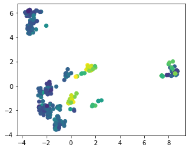

```
[[1.         0.97673449]
 [0.97673449 1.        ]]
```

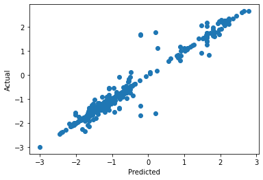